# Estudo Ecológico: População em Aglomerados Subnormais no Brasil

Análise por Unidade da Federação — Censo Demográfico IBGE 2022

czanchetta

14 de abril de 2026

# 1 Introdução

Os aglomerados subnormais — popularmente conhecidos como favelas, comunidades, invasões ou grotas — representam uma das expressões mais visíveis da desigualdade urbana brasileira. Trata-se de assentamentos caracterizados por irregularidade fundiária, precariedade habitacional e insuficiência de infraestrutura urbana básica. O Instituto Brasileiro de Geografia e Estatística (IBGE), em seu Censo Demográfico de 2022, adotou a denominação **Favelas e Comunidades Urbanas** para esse universo, reforçando a relevância do tema no debate sobre desenvolvimento social e saúde coletiva.

Do ponto de vista epidemiológico, o contexto habitacional é um determinante social fundamental da saúde. Populações residentes em aglomerados subnormais enfrentam maior exposição a condições que aumentam o risco de doenças transmissíveis, violência, agravos ambientais e acesso reduzido a serviços de saúde. A compreensão da distribuição geográfica dessa população e de seus correlatos socioeconômicos constitui, portanto, uma etapa indispensável à formulação de políticas de saúde equitativas.

Este estudo ecológico tem por objetivos:

1. Estimar a proporção da população brasileira residente em aglomerados subnormais por **Unidade da Federação (UF)**, com base nos dados do Censo IBGE 2022;
2. Calcular **taxas brutas** e **taxas padronizadas por idade e sexo** (padronização direta) para cada UF;
3. Explorar a associação entre o **rendimento domiciliar per capita** médio estadual e a taxa padronizada de residência em aglomerados subnormais.

A justificativa do desenho ecológico reside na disponibilidade dos dados: o Censo 2022 oferece contagens completas de população por aglomerado subnormal, mas sem vinculação individual a desfechos de saúde. A unidade de análise é, portanto, a UF — e as inferências são restritas a este nível agregado.

# 2 Métodos

## 2.1 Fonte de dados

Os dados utilizados foram obtidos por meio da **API SIDRA v3** do IBGE, acessada programaticamente em R. Foram utilizadas três tabelas do Censo Demográfico 2022:

| Tabela SIDRA | Conteúdo | Variável |
| --- | --- | --- |
| **9884** | População residente em Favelas e Comunidades Urbanas, por sexo e grupo de idade | 9612 |
| **9514** | População residente total, por sexo e idade | 93 |
| **10295** | Valor do rendimento nominal médio mensal domiciliar per capita | 13431 |

## 2.2 Nível de agregação

A análise foi conduzida no nível estadual (27 UFs: 26 estados + Distrito Federal). Não há inferências sobre municípios, regiões metropolitanas ou indivíduos.

## 2.3 Cálculo das taxas

### 2.3.1 Taxa bruta

$$\text{Taxa bruta}_{UF} =
\frac{\text{Pop. em aglomerados subnormais}_{UF}}{\text{Pop.
total}_{UF}} \times 100$$

### 2.3.2 Padronização direta por idade e sexo

A padronização direta permite comparar taxas entre UFs controlando diferenças na estrutura etária e de sexo das populações. A **população padrão** utilizada foi a população brasileira total do Censo 2022 (soma de todos os UFs, $\approx$ 203 milhões de pessoas).

Para cada UF, a taxa padronizada é calculada como:

$$\text{Taxa padronizada}_{UF} =
\sum_{i,j} \left( \frac{\text{Pop. sub}_{ij,UF}}{\text{Pop.
total}_{ij,UF}} \times \frac{\text{Pop. padrão}_{ij}}{\text{Pop. padrão
total}} \right) \times 100$$

onde $i$ = grupo etário quinquenal (0–4, 5–9, …, 95–99, 100+ anos) e $j$ = sexo (Homens, Mulheres). A padronização resultou em 42 células (21 grupos etários × 2 sexos) por UF.

**Validação interna:** a taxa padronizada nacional (todos os UFs agregados usando a própria população como padrão) deve ser idêntica à taxa bruta nacional. A diferença observada foi de 0,000000 pontos percentuais, confirmando a correção do cálculo.

## 2.4 Análise de correlação

A associação entre renda per capita estadual e taxa padronizada de aglomerados subnormais foi avaliada por regressão linear (OLS), com cálculo do coeficiente de Pearson ($r$), $R^2$ e p-valor.

## 2.5 Processamento computacional

Análises realizadas em **R 4.3.3** com os pacotes `tidyverse`, `geobr`, `ggplot2`, `ggrepel`, `broom`, `patchwork` e `writexl`. Controle de ambiente via `renv`.

# 3 Resultados

## 3.1 Estatísticas descritivas

Tabela 1. Taxa bruta e padronizada de população em aglomerados subnormais por UF — Brasil, Censo 2022

| UF | Sigla | Pop. Total | Pop. Aglom. Subnormal | Taxa Bruta (%) | Taxa Padronizada (%) | Renda per capita (R$) |
| --- | --- | --- | --- | --- | --- | --- |
| Amazonas | AM | 3.941.613 | 1.368.098 | 34.71 | 34.55 | 979.58 |
| Amapá | AP | 733.759 | 179.263 | 24.43 | 23.36 | 1142.15 |
| Pará | PA | 8.120.131 | 1.523.519 | 18.76 | 18.97 | 994.00 |
| Espírito Santo | ES | 3.833.712 | 598.377 | 15.61 | 15.67 | 1650.72 |
| Rio de Janeiro | RJ | 16.055.174 | 2.142.394 | 13.34 | 13.61 | 1846.50 |
| Pernambuco | PE | 9.058.931 | 1.091.165 | 12.05 | 12.01 | 1141.02 |
| Bahia | BA | 14.141.626 | 1.370.202 | 9.69 | 9.69 | 1079.17 |
| Ceará | CE | 8.794.957 | 749.637 | 8.52 | 8.49 | 1055.98 |
| Acre | AC | 830.018 | 68.736 | 8.28 | 8.24 | 1067.93 |
| São Paulo | SP | 44.411.238 | 3.630.601 | 8.17 | 8.32 | 2093.44 |
| Maranhão | MA | 6.776.699 | 503.753 | 7.43 | 7.43 | 899.87 |
| Sergipe | SE | 2.210.004 | 160.943 | 7.28 | 7.19 | 1181.90 |
| Distrito Federal | DF | 2.817.381 | 198.769 | 7.06 | 6.94 | 2999.18 |
| Piauí | PI | 3.271.199 | 199.044 | 6.08 | 6.06 | 1009.27 |
| Alagoas | AL | 3.127.683 | 177.889 | 5.69 | 5.61 | 1034.94 |
| Rio Grande do Norte | RN | 3.302.729 | 175.241 | 5.31 | 5.30 | 1246.74 |
| Paraíba | PB | 3.974.687 | 210.631 | 5.30 | 5.29 | 1097.81 |
| Rondônia | RO | 1.581.196 | 83.292 | 5.27 | 5.17 | 1374.14 |
| Paraná | PR | 11.444.380 | 442.119 | 3.86 | 3.89 | 1965.12 |
| Rio Grande do Sul | RS | 10.882.965 | 416.534 | 3.83 | 3.96 | 2042.12 |
| Minas Gerais | MG | 20.539.989 | 739.932 | 3.60 | 3.65 | 1611.89 |
| Tocantins | TO | 1.511.460 | 42.321 | 2.80 | 2.72 | 1392.58 |
| Roraima | RR | 636.707 | 16.009 | 2.51 | 2.34 | 1142.41 |
| Mato Grosso | MT | 3.658.649 | 81.895 | 2.24 | 2.20 | 1825.26 |
| Santa Catarina | SC | 7.610.361 | 109.234 | 1.44 | 1.44 | 2220.40 |
| Goiás | GO | 7.056.495 | 94.514 | 1.34 | 1.33 | 1697.17 |
| Mato Grosso do Sul | MS | 2.757.013 | 16.678 | 0.60 | 0.59 | 1710.13 |

**Nota:** Ordenado por taxa bruta decrescente. O total nacional de população em aglomerados subnormais foi de **16.390.790** pessoas, representando **8.07%** da população brasileira (Censo 2022).

## 3.2 Mapa coroplético — taxa padronizada por UF

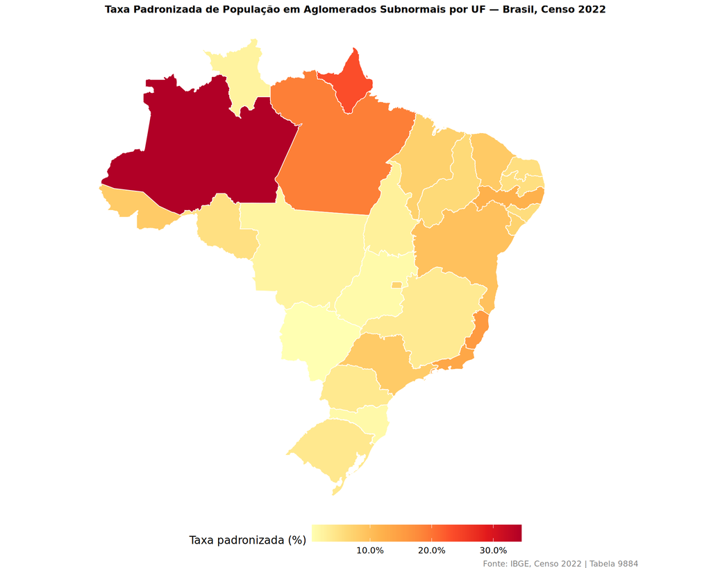

**Figura 1.** O mapa evidencia uma concentração de altas taxas na **Região Norte**, com destaque para Amazonas (34.6%) e Amapá (23.4%). Espírito Santo e Rio de Janeiro destacam-se no Sudeste.

## 3.3 Comparação: taxa bruta vs. taxa padronizada

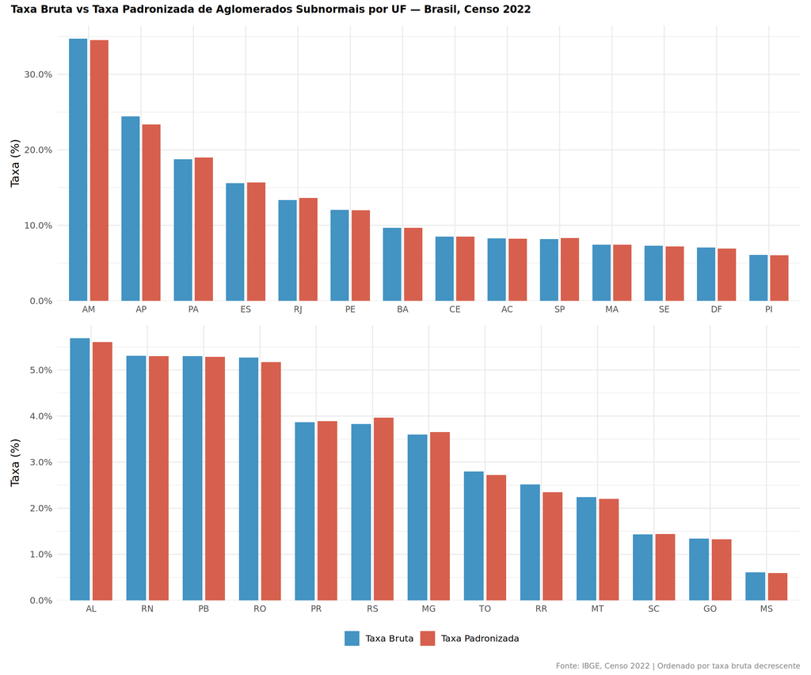

**Figura 2.** As taxas bruta e padronizada são geralmente próximas, indicando que as diferenças entre UFs não se devem primariamente à estrutura etária. A padronização tem maior impacto em estados com populações mais jovens (ex.: Amapá, onde a taxa padronizada é ligeiramente menor que a bruta).

## 3.4 Correlação com renda per capita

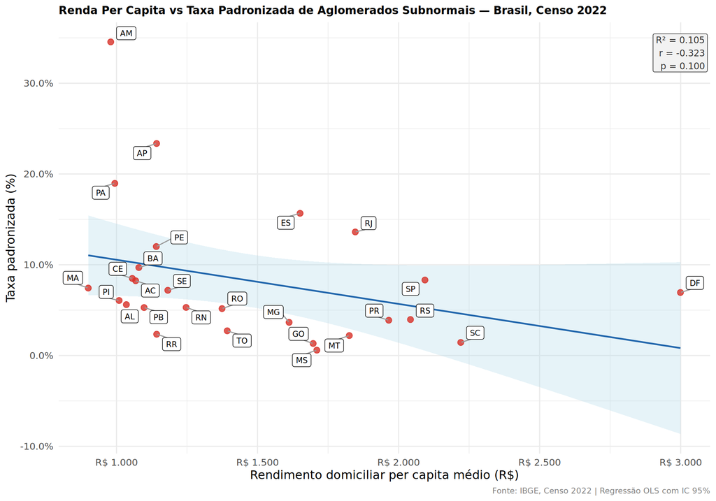

**Figura 3.** A análise de correlação entre renda per capita e taxa padronizada revelou associação negativa ($r$ = -0.323, $R^2$ = 0.105, p = 0.1), indicando que estados com maior renda tendem a ter menor prevalência de população em aglomerados subnormais. Contudo, o coeficiente de determinação baixo e o p-valor limítrofe sugerem que a renda explica apenas parcialmente essa variação no nível estadual.

## 3.5 Estrutura Etária da População em Aglomerados Subnormais

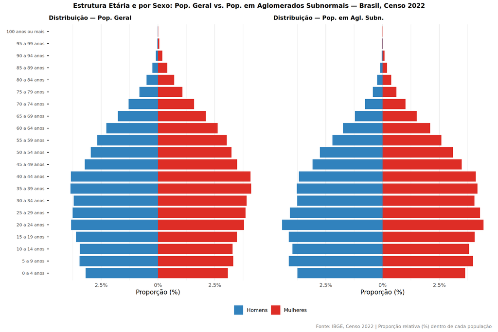

**Figura 4.** Pirâmides etárias comparando a distribuição por sexo e grupo etário da população geral e da população residente em aglomerados subnormais — Brasil, Censo 2022. Homens à esquerda (proporções negativas no eixo x), mulheres à direita.

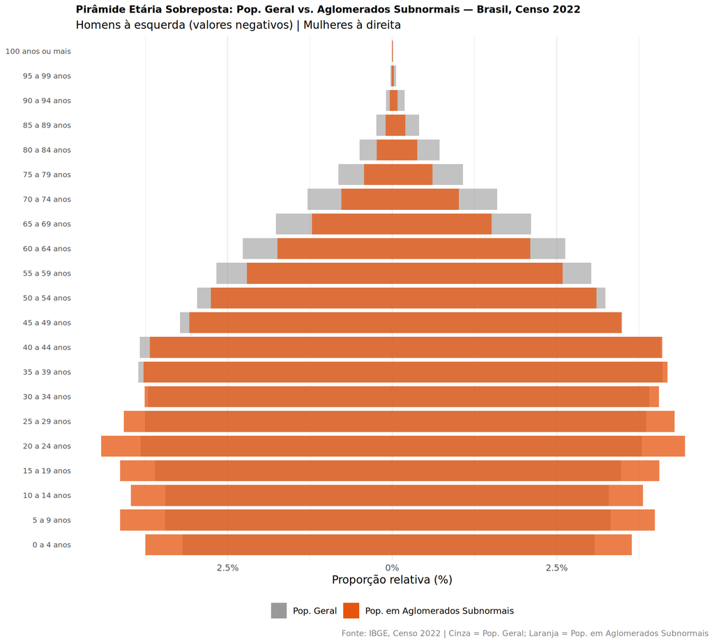

**Figura 5.** Pirâmide sobreposta para comparação direta da estrutura etária. A sobreposição permite identificar visualmente os grupos etários sobre e sub-representados na população favelada em relação à população geral.

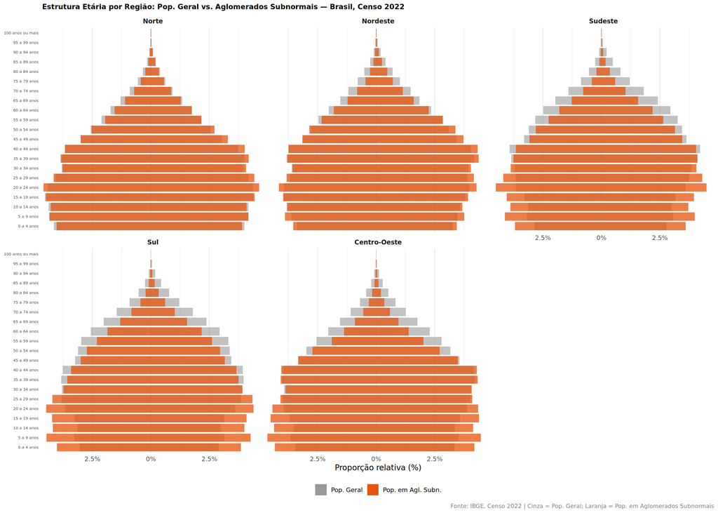

**Figura 6.** Pirâmides etárias sobrepostas por região brasileira. Cada painel compara a distribuição etária da população geral (cinza) com a população residente em aglomerados subnormais (laranja) dentro de cada região.

A análise da estrutura etária da população em aglomerados subnormais revela um perfil demográfico distinto da população geral. A proporção de indivíduos com menos de 30 anos é de **48.7%** na população favelada, contra **42.1%** na população geral — diferença de **6.7 pontos percentuais** —, confirmando que a população em aglomerados subnormais é substancialmente mais jovem. Em sentido inverso, os idosos (60 anos ou mais) representam **10.5%** da população favelada versus **15.8%** da população geral.

Em relação ao sexo, homens constituem **48.3%** da população em aglomerados subnormais e **48.5%** da população geral, indicando que as duas populações têm composição por sexo semelhante no agregado nacional.

Os grupos etários mais **sobre-representados** nas favelas em relação à população geral (razão prop. > 1,10) foram: 5 a 9 anos (Mulheres, razão = 1.2); 5 a 9 anos (Homens, razão = 1.2); 0 a 4 anos (Mulheres, razão = 1.19); 0 a 4 anos (Homens, razão = 1.18); 20 a 24 anos (Mulheres, razão = 1.17). Os grupos mais **sub-representados** (razão < 0,90) foram: 90 a 94 anos (Homens, razão = 0.38); 95 a 99 anos (Homens, razão = 0.4); 85 a 89 anos (Homens, razão = 0.42); 90 a 94 anos (Mulheres, razão = 0.44); 95 a 99 anos (Mulheres, razão = 0.45). A tabela completa de razões de proporção por grupo etário e sexo encontra-se em `outputs/tables/piramide_dados.xlsx`.

# 4 Discussão

Os resultados indicam heterogeneidade expressiva na distribuição de população em aglomerados subnormais entre as UFs brasileiras. O Amazonas apresenta a maior taxa padronizada (34.6%), seguido por Amapá (23.4%) e Pará (19%), sugerindo que condições específicas da Região Norte — incluindo padrão de urbanização, fragilidade fundiária e pressão migratória para centros urbanos — contribuem para maior concentração de moradores em assentamentos informais.

A proximidade entre taxas brutas e padronizadas indica que a estrutura etária das populações estaduais tem impacto limitado nas comparações entre UFs. Isso é esperado em um contexto onde as populações adultas jovens predominam amplamente nos aglomerados subnormais em todo o território nacional.

A associação inversa entre renda per capita e proporção de população em aglomerados subnormais é consistente com determinantes socioeconômicos estruturais. Contudo, a magnitude modesta do $R^2$ (0.105) e o p-valor de 0.1 apontam para a insuficiência da renda per capita estadual como único preditor, o que é esperado: outros fatores como mercado fundiário, políticas habitacionais, histórico de urbanização e composição migratória contribuem de forma independente.

Destaca-se que o Espírito Santo e o Rio de Janeiro apresentam taxas padronizadas elevadas apesar de rendas per capita intermediárias-altas, refletindo processos históricos de favelização em grandes aglomerados urbanos (Região Metropolitana da Grande Vitória e Região Metropolitana do Rio de Janeiro).

# 5 Limitações

Este estudo apresenta limitações inerentes ao seu desenho ecológico, que devem ser consideradas na interpretação dos resultados:

1. **Falácia ecológica:** As associações observadas no nível estadual não podem ser extrapoladas para o nível individual. Um estado com alta taxa de população em aglomerados subnormais e alta renda pode ter, individualmente, os moradores mais ricos não sendo os residentes em favelas.
2. **Pequeno número de unidades de análise (n = 27 UFs):** O poder estatístico para detectar associações é limitado. Análises em nível municipal proporcionariam maior variabilidade e robustez estatística.
3. **Impossibilidade de inferência causal:** O desenho transversal ecológico não permite estabelecer relações causais entre as variáveis estudadas.
4. **Limitações do conceito de aglomerado subnormal como proxy de favela:** O critério do IBGE captura um conjunto específico de assentamentos identificados a priori pelos setores censitários. Assentamentos precários isolados ou em processo inicial de formação podem não ser captados, possivelmente subestimando a real proporção de moradores em condições habitacionais inadequadas.
5. **Variável de renda:** O rendimento domiciliar per capita médio é derivado do questionário amostral do Censo 2022 (~10% dos domicílios), o que implica maior incerteza de estimativa em estados menores.
6. **Ausência de ajuste por confundidores:** Outras variáveis potencialmente confundidoras (taxa de urbanização, densidade populacional, acesso a saneamento) não foram incluídas na análise de correlação.

# 6 Referências

- Instituto Brasileiro de Geografia e Estatística — IBGE. **Censo Demográfico 2022: Favelas e Comunidades Urbanas**. Rio de Janeiro: IBGE, 2024. Disponível em: https://www.ibge.gov.br
- Instituto Brasileiro de Geografia e Estatística — IBGE. **API SIDRA v3** — Sistema IBGE de Recuperação Automática. Disponível em: https://servicodados.ibge.gov.br/api/docs/agregados
- SZKLO, M.; NIETO, F.J. **Epidemiology: Beyond the Basics**. 4th ed. Burlington: Jones & Bartlett Learning, 2019.
- ROTHMAN, K.J.; GREENLAND, S.; LASH, T.L. **Modern Epidemiology**. 3rd ed. Philadelphia: Lippincott Williams & Wilkins, 2008.
- Pebesma E (2018). “Simple Features for R: Standardized Support for Spatial Vector Data.” *The R Journal*, 10(1), 439–446.
- Freire D, Cota W, Carvalho L (2023). **geobr: Loads Shapefiles of Official Spatial Data Sets of Brazil**. R package version 1.9.0.

*Análise realizada com dados públicos do Censo Demográfico 2022 (IBGE).*